# Lab 03 - Ruido y outliers

# Solución Lab 03

Missing values

## Librerías

```r
library("ggplot2")
library("readr")
library("dplyr")
library("highcharter")
library("treemap")
library("modeest")
library("GGally")
library("tidyverse")
library("hrbrthemes")
library("tidyr")
library("Rlof")
```

## Leemos el txt

```r
data <- read.table('C:\\Users\\Lucas\\Desktop\\2019\\Data minning\\DataMiningUba2020\\Tps\\Lab03\\ruidoso.txt',
                   sep=',', header =TRUE, strip.white = T, stringsAsFactors = T)
```

## Primeras transformaciones

```r
data[1] <- NULL
```

## Primer vistazo del dataset

```r
str(data)
```

```
'data.frame':   66 obs. of  4 variables:
 $ Road_55dB    : int  166400 20000 37800 24500 103100 36800 39700 388000 15000 18600 ...
 $ Road_60dB    : int  79200 11000 18000 16700 33500 16100 16800 185200 9400 12000 ...
 $ Railways_65dB: int  1100 0 0 0 1900 0 0 300 300 0 ...
 $ Industry_65dB: int  0 0 0 100 200 100 300 1300 200 100 ...
```

```r
summary(data)
```

```
   Road_55dB         Road_60dB       Railways_65dB   Industry_65dB
 Min.   :   7600   Min.   :   4000   Min.   :    0   Min.   :   0
 1st Qu.:  18950   1st Qu.:  10075   1st Qu.:    0   1st Qu.:   0
 Median :  37550   Median :  17400   Median :  100   Median :   0
 Mean   : 159229   Mean   :  78588   Mean   : 1139   Mean   : 180
 3rd Qu.:  78900   3rd Qu.:  34500   3rd Qu.:  400   3rd Qu.: 100
 Max.   :3108200   Max.   :1469100   Max.   :29700   Max.   :4000
                                                     NA's   :1
```

### Columnas numéricas

```r
num_cols <- names(data)[sapply(data, is.numeric)]
num_cols
```

```
[1] "Road_55dB"     "Road_60dB"     "Railways_65dB" "Industry_65dB"
```

### Datos nulos

1 en la última columna

```r
print(data[rowSums(is.na(data)) > 0,])
```

|  | Road_55dB | Road_60dB | Railways_65dB | Industry_65dB |
| --- | --- | --- | --- | --- |
| 66 | 3108200 | 1469100 | 25800 | NA |

### Algunas transformaciones

```r
no_na_data$Road_55dB[no_na_data$Road_55dB  == 0]  <- 0.0000001
no_na_data$Road_60dB[no_na_data$Road_60dB  == 0]  <- 0.0000001
no_na_data$Railways_65dB[no_na_data$Railways_65dB  == 0]  <- 0.0000001
no_na_data$Industry_65dB[no_na_data$Industry_65dB == 0]  <- 0.0000001
data_log <- as.data.frame(apply(data[num_cols], 2, log))
```

## Distribución de los datos

Los datos se aproximan a una exponencial. Algunas gráficas son más claras, otras pareciera haber menos mediciones.

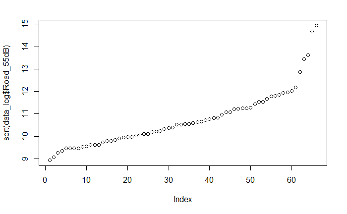

```r
plot(sort(data_log$Road_55dB))
```

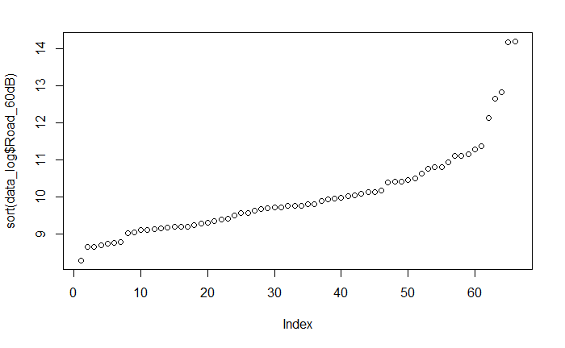

```r
plot(sort(data_log$Road_60dB))
```

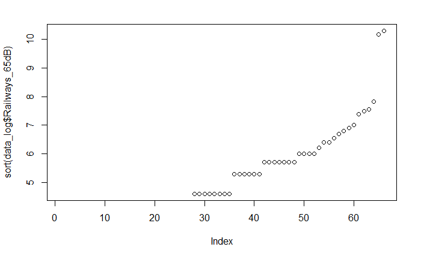

```r
plot(sort(data_log$Railways_65dB))
```

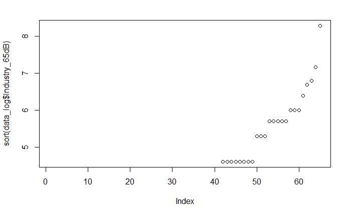

```r
plot(sort(data_log$Industry_65dB))
```

## Boxplots

Toca aplicar logaritmo, debido a que por la propria naturaleza del dato tiene una curva exponencial

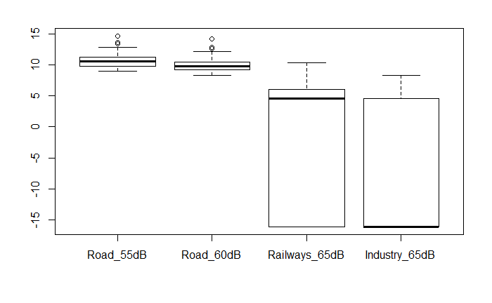

```r
no_na_data <- data %>% filter(!is.na(Industry_65dB))
no_na_data$Road_55dB[no_na_data$Road_55dB  == 0]  <- 0.0000001
no_na_data$Road_60dB[no_na_data$Road_60dB  == 0]  <- 0.0000001
no_na_data$Railways_65dB[no_na_data$Railways_65dB  == 0]  <- 0.0000001
no_na_data$Industry_65dB[no_na_data$Industry_65dB == 0]  <- 0.0000001
data_log <- as.data.frame(apply(no_na_data[num_cols], 2, log))
boxplot(data_log, use.cols = TRUE, title="Boxplot")
```

Aislando los boxplots de Road

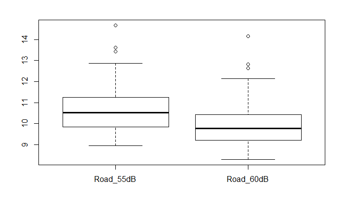

```r
boxplot(data_log[c('Road_55dB', 'Road_60dB')], use.cols = TRUE, title="Boxplot")
```

### Correlación

Hay algo interesante en el gráfico de la correlación se aprecia que un gráfico muy parecido al de la ley de las potencias.

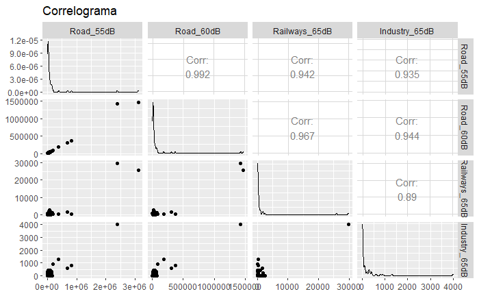

```r
ggpairs(data[num_cols], title="Correlograma")
```

Siguiendo la misma lógica que para los boxplot, es mejor realizar el gráfico luego de aplicar la función logaritmica

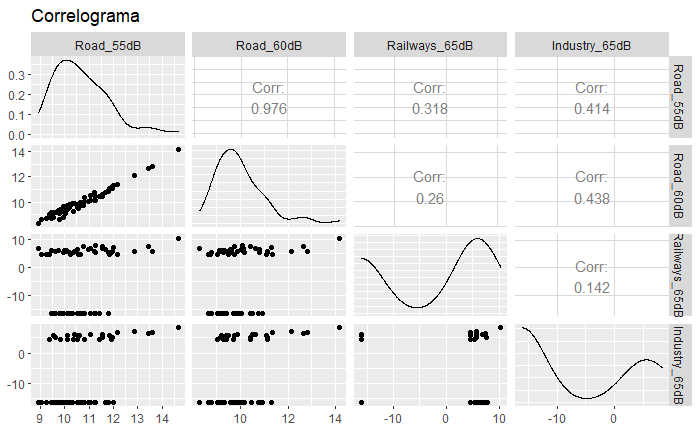

```r
ggpairs(data_log[num_cols], title="Correlograma")
```

## Valores anómalos - Metodos Univariado

### Boxplot y IQR

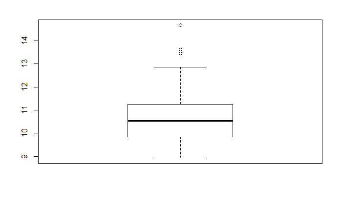

```r
bp = boxplot(data_log$Road_55dB)
```

```r
out_inf = bp$stats[1]
out_sup = bp$stats[5]
cat("Extremo inferior", out_inf)
```

```
Extremo inferior 8.935904
```

```r
cat("Extremo superior", out_sup)
```

```
Extremo superior 12.86876
```

#### Version sin recortar

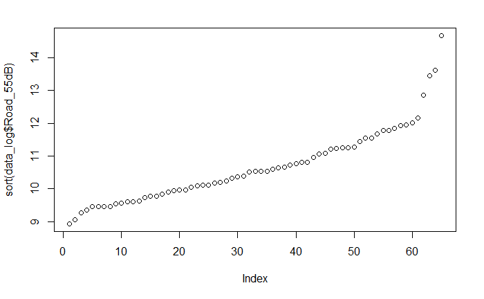

```r
plot(sort(data_log$Road_55dB))
```

#### Versión recortando

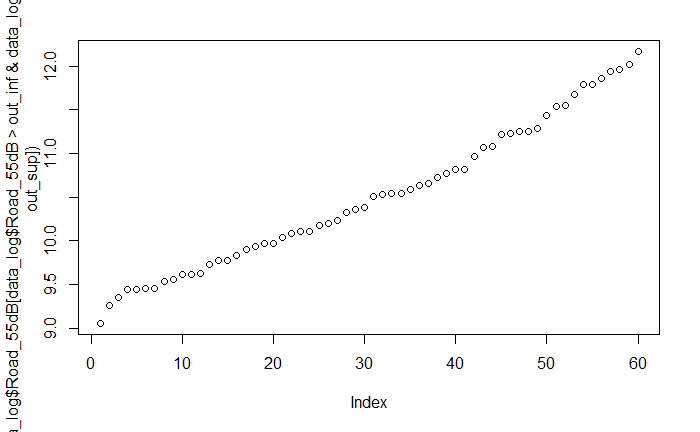

```r
plot(sort(data_log$Road_55dB[data_log$Road_55dB>out_inf & data_log$Road_55dB<out_sup]))
```

### Desvíos de la Media

```r
N=3
desvio<-sd(data_log$Road_55dB)
print(desvio)
```

```
[1] 1.136121
```

```r
outliers_max<-mean(data_log$Road_55dB)+N*desvio
print(outliers_max)
```

```
[1] 14.08717
```

```r
outliers_min<-mean(data_log$Road_55dB)-N*desvio
```

#### Plot

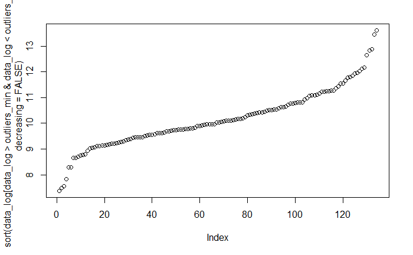

```r
plot(sort(data_log[data_log>outliers_min & data_log<outliers_max], decreasing = FALSE))
```

## Z-Score

```r
data_log$zscore<-(data_log$Road_55dB-mean(data_log$Road_55dB))/sd(data_log$Road_55dB)
umbral<-2
max(data_log$zscore)
```

```
[1] 3.526759
```

```r
min(data_log$zscore)
```

```
[1] -1.534082
```

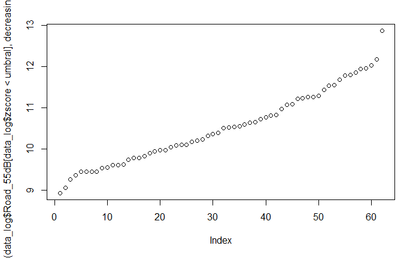

```r
plot(sort(data_log$Road_55dB[data_log$zscore<umbral], decreasing = FALSE))
```

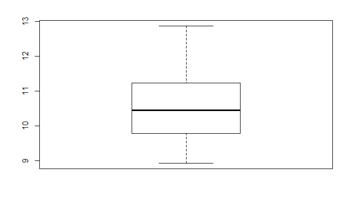

```r
boxplot(sort(data_log$Road_55dB[data_log$zscore<umbral], decreasing = FALSE))
```

#### Conclusiones parciales

Tiende a pasar que recorto outliers, pero a partir de ahí se recalcula la media, el IQR, entonces vuelven a surgir outliers.

## Valores anómalos - Metodos multivariado

### LOF

Con mayor umbral, menos sensibilidad a los outliers. 1 o menos ya toma todos. A partir de 2 se comporta mejor en este gráfico.

```r
data$score <- lof(data[num_cols], k=5)
umbral <- 2.5
data$outlier <- (data$score > umbral)
# data$result_rlof <- na.omit(data[num_cols])
data$color <- ifelse(data$outlier, "red", "black")
```

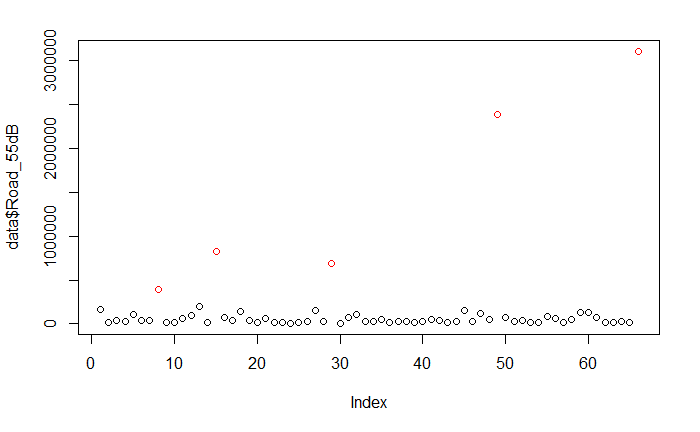

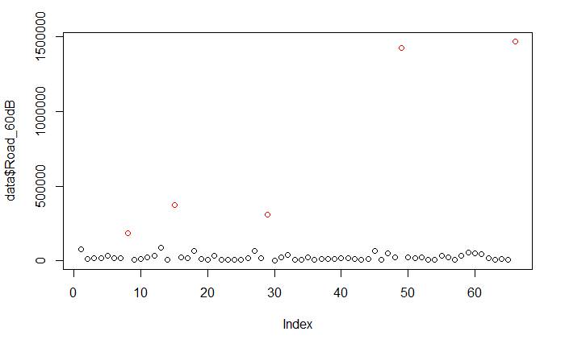

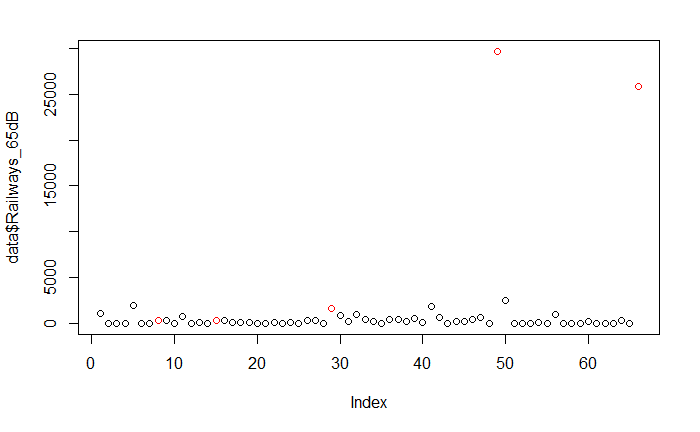

```r
plot(data$Road_55dB, col=data$color)
plot(data$Road_60dB, col=data$color)

plot(data$Railways_65dB, col=data$color)
```

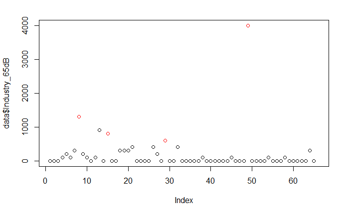

```r
plot(data$Industry_65dB, col=data$color)
```

### Distancia de Mahalanobis

```r
no_na_data$mahalanobis <- mahalanobis(no_na_data[,num_cols], colMeans(no_na_data[,num_cols]), cov(no_na_data[,num_cols]))
```

#### Ordenamos de forma decreciente, según el score de Mahalanobis

```r
no_na_data <- no_na_data[order(no_na_data$mahalanobis, decreasing = TRUE),]
```

```r
no_na_data
```

[output not shown]

[output cut: 55 more lines]

#### Descartamos los outliers según un umbral

A mayor umbral somos más restrictivos a la hora de tomar los outliers. Con un umbral de 1, prácticamento la mitad de los valores son tomados como outliers. A partir de 8 tenemos una mejor selección, haciendo distintas pruebas tomé como valor 13.

```r
umbral <- 13
no_na_data$outlier <- (no_na_data$mahalanobis > umbral)
no_na_data$color <- ifelse(no_na_data$mahalanobis > umbral, "red", "black")
```

#### Plots

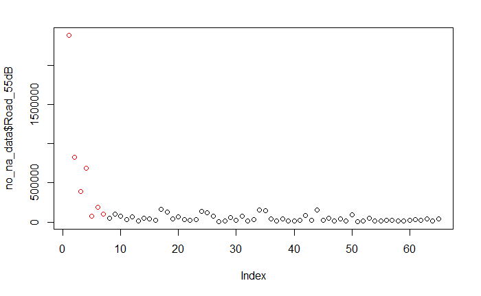

```r
plot(no_na_data$Road_55dB, col=no_na_data$color)
```

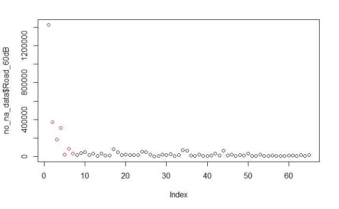

```r
plot(no_na_data$Road_60dB, col=no_na_data$color)
```

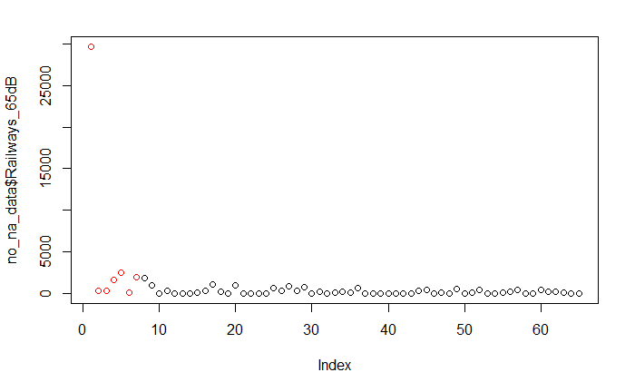

```r
plot(no_na_data$Railways_65dB, col=no_na_data$color)
```

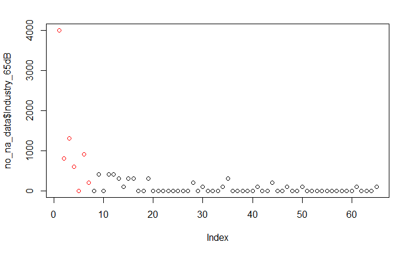

```r
plot(no_na_data$Industry_65dB, col=no_na_data$color)
```